# Product Insight Sales

```r
#rm(list = ls())
```

## libaries used for the project

```r
library(DBI)
library (RSQLite)
library(tidyverse)
library(tibble)
library(ggplot2)
library(rpart)
library(rpart.plot)
library(caret)
library(corrplot)
```

# Connecting to the Database

The dataset is stored in a SQLite database file named **`project1_raw_data.db`**, which is saved in the Desktop folder. The `RSQLite` package is used to establish a connection to the database. Once connected, the `PRAGMA table_info(weather)` query is executed to inspect the structure of the `weather` table, including its column names and data types.

```r
con <- dbConnect(
  RSQLite:: SQLite(),
  "/Users/AshishLama/Desktop/project1_raw_data.db"
)

data = dbGetQuery(con, "PRAGMA table_info(weather)")
```

# Retrieving and Joining the Data

The following SQL query extracts the required variables by joining the `train`, `key`, and `weather` tables. The `train` table is linked to the `key` table using `store_nbr`, while the `weather` table is joined using both `station_nbr` and `date`. This creates a single dataset containing sales information together with the corresponding weather conditions for each store and date.

```r
df <- dbGetQuery(con, "

                 SELECT
                 t.date,
                 t.units,
                 t.store_nbr,
                 t.item_nbr,
                 w.station_nbr,
                 w.tavg,
                 w.preciptotal,
                 w.codesum,
                 w.tmax,
                 w.tmin,
                 w.dewpoint,
                 w.wetbulb,
                 w.heat,
                 w.cool,
                 w.sealevel,
                 w.resultdir

                FROM train t

                JOIN key k ON t.store_nbr = k.store_nbr

                JOIN weather w ON k.station_nbr = w.station_nbr AND t.date = w.date

                 ")
```

checking the dataframe

```r
df
```

| date | units | store_nbr | item_nbr | station_nbr | tavg | preciptotal | codesum | tmax | tmin | dewpoint | wetbulb | heat | cool | sealevel | resultdir |
| --- | --- | --- | --- | --- | --- | --- | --- | --- | --- | --- | --- | --- | --- | --- | --- |
| 2012-01-01 | 0 | 1 | 1 | 1 | 42 | 0.05 | RA FZFG BR | 52 | 31 | 36 | 40 | 23 | 0 | 29.92 | 20 |
| 2012-01-01 | 0 | 1 | 2 | 1 | 42 | 0.05 | RA FZFG BR | 52 | 31 | 36 | 40 | 23 | 0 | 29.92 | 20 |
| 2012-01-01 | 0 | 1 | 3 | 1 | 42 | 0.05 | RA FZFG BR | 52 | 31 | 36 | 40 | 23 | 0 | 29.92 | 20 |
| 2012-01-01 | 0 | 1 | 4 | 1 | 42 | 0.05 | RA FZFG BR | 52 | 31 | 36 | 40 | 23 | 0 | 29.92 | 20 |
| 2012-01-01 | 0 | 1 | 5 | 1 | 42 | 0.05 | RA FZFG BR | 52 | 31 | 36 | 40 | 23 | 0 | 29.92 | 20 |
| 2012-01-01 | 0 | 1 | 6 | 1 | 42 | 0.05 | RA FZFG BR | 52 | 31 | 36 | 40 | 23 | 0 | 29.92 | 20 |
| 2012-01-01 | 0 | 1 | 7 | 1 | 42 | 0.05 | RA FZFG BR | 52 | 31 | 36 | 40 | 23 | 0 | 29.92 | 20 |
| 2012-01-01 | 0 | 1 | 8 | 1 | 42 | 0.05 | RA FZFG BR | 52 | 31 | 36 | 40 | 23 | 0 | 29.92 | 20 |
| 2012-01-01 | 29 | 1 | 9 | 1 | 42 | 0.05 | RA FZFG BR | 52 | 31 | 36 | 40 | 23 | 0 | 29.92 | 20 |
| 2012-01-01 | 0 | 1 | 10 | 1 | 42 | 0.05 | RA FZFG BR | 52 | 31 | 36 | 40 | 23 | 0 | 29.92 | 20 |

[output cut: 990 more lines]

```r
# view(df)
```

# Closing the Database Connection

After the required data has been extracted, the database connection is closed to release system resources and ensure that the connection is properly terminated.

```r
dbDisconnect(con)
```

# Exploring the dataset

A summary of the dataset is generated to provide descriptive statistics and identify the distribution of each variable

```r
summary(df)
```

```
     date               units             store_nbr        item_nbr    station_nbr         tavg
 Length:4617600     Min.   :   0.0000   Min.   : 1.00   Min.   :  1   Min.   : 1.00   Min.   :-16.00
 Class :character   1st Qu.:   0.0000   1st Qu.:12.00   1st Qu.: 28   1st Qu.: 7.00   1st Qu.: 48.00
 Mode  :character   Median :   0.0000   Median :23.00   Median : 56   Median :12.00   Median : 64.00
                    Mean   :   0.9869   Mean   :23.09   Mean   : 56   Mean   :11.32   Mean   : 61.18
                    3rd Qu.:   0.0000   3rd Qu.:34.00   3rd Qu.: 84   3rd Qu.:15.00   3rd Qu.: 77.00
                    Max.   :5568.0000   Max.   :45.00   Max.   :111   Max.   :20.00   Max.   :100.00
                                                                                      NA's   :187701
  preciptotal      codesum               tmax             tmin           dewpoint         wetbulb
 Min.   :0.000   Length:4617600     Min.   :-11.00   Min.   :-21.0    Min.   :-24.00   Min.   :-15.0
 1st Qu.:0.000   Class :character   1st Qu.: 60.00   1st Qu.: 35.0    1st Qu.: 31.00   1st Qu.: 41.0
 Median :0.000   Mode  :character   Median : 76.00   Median : 52.0    Median : 49.00   Median : 56.0
 Mean   :0.079                      Mean   : 72.08   Mean   : 49.9    Mean   : 46.07   Mean   : 53.2
 3rd Qu.:0.050                      3rd Qu.: 87.00   3rd Qu.: 66.0    3rd Qu.: 63.00   3rd Qu.: 68.0
 Max.   :7.360                      Max.   :114.00   Max.   : 88.0    Max.   : 77.00   Max.   : 80.0
 NA's   :98901                      NA's   :111444   NA's   :111333   NA's   :91020    NA's   :167499
      heat             cool           sealevel        resultdir
 Min.   : 0.00    Min.   : 0.000   Min.   :29.16    Min.   : 1.00
 1st Qu.: 0.00    1st Qu.: 0.000   1st Qu.:29.90    1st Qu.:13.00
 Median : 1.00    Median : 0.000   Median :30.01    Median :18.00
 Mean   : 9.63    Mean   : 5.813   Mean   :30.02    Mean   :18.34
 3rd Qu.:17.00    3rd Qu.:12.000   3rd Qu.:30.13    3rd Qu.:25.00
 Max.   :81.00    Max.   :35.000   Max.   :30.80    Max.   :36.00
 NA's   :187701   NA's   :187701   NA's   :214674   NA's   :75480
```

```r
sapply(df, class)
```

```
       date       units   store_nbr    item_nbr station_nbr        tavg preciptotal     codesum        tmax
"character"   "integer"   "integer"   "integer"   "integer"   "integer"   "numeric" "character"   "integer"
       tmin    dewpoint     wetbulb        heat        cool    sealevel   resultdir
  "integer"   "integer"   "integer"   "integer"   "integer"   "numeric"   "integer"
```

## DATA WANGLING

```r
df_clean <- df
```

```r
# creating the columns names under 'var'.
var <- c("tavg", "preciptotal", "tmax", "tmin", "dewpoint", "wetbulb", "heat", "cool", "sealevel", "resultdir")
```

we can see there are a lot of the NA’s in the provided columns on var. we see if the there are NA and see the whitespacesand convert it into NA on the columns. After that we replace the NA into the mean value.

```r
mean_val <- colMeans(df_clean[, var], na.rm = TRUE)

#replacing NA with mean value of each column

for (i in var){
  # treating whitespace as NA
  df_clean[,i][df_clean[,i] == ""| df_clean[, i] == " "] <- NA

  #replacing the NA with mean
  df_clean[,i][is.na(df_clean[,i])] <- mean_val[i]
}
```

We can see that there are no NA in the provided columns.

```r
summary(df_clean)
```

```
     date               units             store_nbr        item_nbr    station_nbr         tavg
 Length:4617600     Min.   :   0.0000   Min.   : 1.00   Min.   :  1   Min.   : 1.00   Min.   :-16.00
 Class :character   1st Qu.:   0.0000   1st Qu.:12.00   1st Qu.: 28   1st Qu.: 7.00   1st Qu.: 49.00
 Mode  :character   Median :   0.0000   Median :23.00   Median : 56   Median :12.00   Median : 63.00
                    Mean   :   0.9869   Mean   :23.09   Mean   : 56   Mean   :11.32   Mean   : 61.18
                    3rd Qu.:   0.0000   3rd Qu.:34.00   3rd Qu.: 84   3rd Qu.:15.00   3rd Qu.: 76.00
                    Max.   :5568.0000   Max.   :45.00   Max.   :111   Max.   :20.00   Max.   :100.00
  preciptotal        codesum               tmax             tmin          dewpoint         wetbulb
 Min.   :0.00000   Length:4617600     Min.   :-11.00   Min.   :-21.0   Min.   :-24.00   Min.   :-15.00
 1st Qu.:0.00000   Class :character   1st Qu.: 61.00   1st Qu.: 36.0   1st Qu.: 31.00   1st Qu.: 41.00
 Median :0.00000   Mode  :character   Median : 75.00   Median : 51.0   Median : 48.00   Median : 55.00
 Mean   :0.07933                      Mean   : 72.08   Mean   : 49.9   Mean   : 46.07   Mean   : 53.21
 3rd Qu.:0.05000                      3rd Qu.: 87.00   3rd Qu.: 66.0   3rd Qu.: 63.00   3rd Qu.: 67.00
 Max.   :7.36000                      Max.   :114.00   Max.   : 88.0   Max.   : 77.00   Max.   : 80.00
      heat            cool           sealevel       resultdir
 Min.   : 0.00   Min.   : 0.000   Min.   :29.16   Min.   : 1.00
 1st Qu.: 0.00   1st Qu.: 0.000   1st Qu.:29.90   1st Qu.:13.00
 Median : 2.00   Median : 0.000   Median :30.02   Median :18.00
 Mean   : 9.63   Mean   : 5.813   Mean   :30.02   Mean   :18.34
 3rd Qu.:16.00   3rd Qu.:11.000   3rd Qu.:30.12   3rd Qu.:25.00
 Max.   :81.00   Max.   :35.000   Max.   :30.80   Max.   :36.00
```

checking the class of the columns.

```r
sapply(df_clean,class)
```

```
       date       units   store_nbr    item_nbr station_nbr        tavg preciptotal     codesum        tmax
"character"   "integer"   "integer"   "integer"   "integer"   "numeric"   "numeric" "character"   "numeric"
       tmin    dewpoint     wetbulb        heat        cool    sealevel   resultdir
  "numeric"   "numeric"   "numeric"   "numeric"   "numeric"   "numeric"   "numeric"
```

we can see the date is on the character we are going to change the class into Date.

```r
Sys.Date()
```

```
[1] "2026-09-06"
```

```r
df_clean$date <- as.Date(df_clean$date, format = '%Y-%m-%d')
```

checking the class of the columns.

```r
sapply(df_clean,class)
```

```
       date       units   store_nbr    item_nbr station_nbr        tavg preciptotal     codesum        tmax
     "Date"   "integer"   "integer"   "integer"   "integer"   "numeric"   "numeric" "character"   "numeric"
       tmin    dewpoint     wetbulb        heat        cool    sealevel   resultdir
  "numeric"   "numeric"   "numeric"   "numeric"   "numeric"   "numeric"   "numeric"
```

From date we will be creating two features to do analysis.

```r
# creating the day features from the date.
df_clean$day <- weekdays(df_clean$date)

# creating the month features from the date
df_clean$month <- as.integer((format(df_clean$date, "%m")))
```

```r
df_clean <- df_clean %>%
  mutate(
    is_weekends = as.integer((day %in% (c("Saturday", "Sunday")))),
    is_weekdays = as.integer(day %in% (c("Monday", "Tuesday","Wednesaday","Thrusday","Friday")))
  )
```

Black entries in the codesum variables are replaced with the ‘moderate’.

```r
df_clean <- df_clean %>%
  mutate(codesum = ifelse(codesum == "" | codesum == " ", "Moderate", codesum))
```

vewing the dataframe.

```r
df_clean
```

| date | units | store_nbr | item_nbr | station_nbr | tavg | preciptotal | codesum | tmax | tmin | dewpoint | wetbulb | heat | cool | sealevel | resultdir | day | month | is_weekends | is_weekdays |
| --- | --- | --- | --- | --- | --- | --- | --- | --- | --- | --- | --- | --- | --- | --- | --- | --- | --- | --- | --- |
| 2012-01-01 | 0 | 1 | 1 | 1 | 42 | 0.05 | RA FZFG BR | 52 | 31 | 36 | 40 | 23 | 0 | 29.92 | 20 | Sunday | 1 | 1 | 0 |
| 2012-01-01 | 0 | 1 | 2 | 1 | 42 | 0.05 | RA FZFG BR | 52 | 31 | 36 | 40 | 23 | 0 | 29.92 | 20 | Sunday | 1 | 1 | 0 |
| 2012-01-01 | 0 | 1 | 3 | 1 | 42 | 0.05 | RA FZFG BR | 52 | 31 | 36 | 40 | 23 | 0 | 29.92 | 20 | Sunday | 1 | 1 | 0 |
| 2012-01-01 | 0 | 1 | 4 | 1 | 42 | 0.05 | RA FZFG BR | 52 | 31 | 36 | 40 | 23 | 0 | 29.92 | 20 | Sunday | 1 | 1 | 0 |
| 2012-01-01 | 0 | 1 | 5 | 1 | 42 | 0.05 | RA FZFG BR | 52 | 31 | 36 | 40 | 23 | 0 | 29.92 | 20 | Sunday | 1 | 1 | 0 |
| 2012-01-01 | 0 | 1 | 6 | 1 | 42 | 0.05 | RA FZFG BR | 52 | 31 | 36 | 40 | 23 | 0 | 29.92 | 20 | Sunday | 1 | 1 | 0 |
| 2012-01-01 | 0 | 1 | 7 | 1 | 42 | 0.05 | RA FZFG BR | 52 | 31 | 36 | 40 | 23 | 0 | 29.92 | 20 | Sunday | 1 | 1 | 0 |
| 2012-01-01 | 0 | 1 | 8 | 1 | 42 | 0.05 | RA FZFG BR | 52 | 31 | 36 | 40 | 23 | 0 | 29.92 | 20 | Sunday | 1 | 1 | 0 |
| 2012-01-01 | 29 | 1 | 9 | 1 | 42 | 0.05 | RA FZFG BR | 52 | 31 | 36 | 40 | 23 | 0 | 29.92 | 20 | Sunday | 1 | 1 | 0 |
| 2012-01-01 | 0 | 1 | 10 | 1 | 42 | 0.05 | RA FZFG BR | 52 | 31 | 36 | 40 | 23 | 0 | 29.92 | 20 | Sunday | 1 | 1 | 0 |

[output cut: 990 more lines]

Creating Weather Indicator Variables

The ‘codesum’ variable is transform into binary indicators for the several weather conditions. if the weather condition is presennt it will contain 1 else 0.

```r
df_clean <- df_clean %>%
  mutate(
    is_clear  = as.integer(grepl("Moderate", codesum)),
    is_rainy  = as.integer(grepl("RA|DZ|PY|SH", codesum)),
    is_snowy  = as.integer(grepl("SN|SG|GS|FZ|IC|PL", codesum)),
    is_foggy  = as.integer(grepl("FG|BR|HZ", codesum)),
    is_stormy = as.integer(grepl("DS|SS|BL|PO|DU", codesum))
  )
```

viewing the dataframe

```r
df_clean
```

| date | units | store_nbr | item_nbr | station_nbr | tavg | preciptotal | codesum | tmax | tmin | dewpoint | wetbulb | heat | cool | sealevel | resultdir | day | month | is_weekends | is_weekdays | is_clear | is_rainy | is_snowy | is_foggy | is_stormy |
| --- | --- | --- | --- | --- | --- | --- | --- | --- | --- | --- | --- | --- | --- | --- | --- | --- | --- | --- | --- | --- | --- | --- | --- | --- |
| 2012-01-01 | 0 | 1 | 1 | 1 | 42 | 0.05 | RA FZFG BR | 52 | 31 | 36 | 40 | 23 | 0 | 29.92 | 20 | Sunday | 1 | 1 | 0 | 0 | 1 | 1 | 1 | 0 |
| 2012-01-01 | 0 | 1 | 2 | 1 | 42 | 0.05 | RA FZFG BR | 52 | 31 | 36 | 40 | 23 | 0 | 29.92 | 20 | Sunday | 1 | 1 | 0 | 0 | 1 | 1 | 1 | 0 |
| 2012-01-01 | 0 | 1 | 3 | 1 | 42 | 0.05 | RA FZFG BR | 52 | 31 | 36 | 40 | 23 | 0 | 29.92 | 20 | Sunday | 1 | 1 | 0 | 0 | 1 | 1 | 1 | 0 |
| 2012-01-01 | 0 | 1 | 4 | 1 | 42 | 0.05 | RA FZFG BR | 52 | 31 | 36 | 40 | 23 | 0 | 29.92 | 20 | Sunday | 1 | 1 | 0 | 0 | 1 | 1 | 1 | 0 |
| 2012-01-01 | 0 | 1 | 5 | 1 | 42 | 0.05 | RA FZFG BR | 52 | 31 | 36 | 40 | 23 | 0 | 29.92 | 20 | Sunday | 1 | 1 | 0 | 0 | 1 | 1 | 1 | 0 |
| 2012-01-01 | 0 | 1 | 6 | 1 | 42 | 0.05 | RA FZFG BR | 52 | 31 | 36 | 40 | 23 | 0 | 29.92 | 20 | Sunday | 1 | 1 | 0 | 0 | 1 | 1 | 1 | 0 |
| 2012-01-01 | 0 | 1 | 7 | 1 | 42 | 0.05 | RA FZFG BR | 52 | 31 | 36 | 40 | 23 | 0 | 29.92 | 20 | Sunday | 1 | 1 | 0 | 0 | 1 | 1 | 1 | 0 |
| 2012-01-01 | 0 | 1 | 8 | 1 | 42 | 0.05 | RA FZFG BR | 52 | 31 | 36 | 40 | 23 | 0 | 29.92 | 20 | Sunday | 1 | 1 | 0 | 0 | 1 | 1 | 1 | 0 |
| 2012-01-01 | 29 | 1 | 9 | 1 | 42 | 0.05 | RA FZFG BR | 52 | 31 | 36 | 40 | 23 | 0 | 29.92 | 20 | Sunday | 1 | 1 | 0 | 0 | 1 | 1 | 1 | 0 |
| 2012-01-01 | 0 | 1 | 10 | 1 | 42 | 0.05 | RA FZFG BR | 52 | 31 | 36 | 40 | 23 | 0 | 29.92 | 20 | Sunday | 1 | 1 | 0 | 0 | 1 | 1 | 1 | 0 |

[output cut: 990 more lines]

## Filtering Data for the Top Three Items

The datasets is filtered to retain only observations corresponding to the three highest-selling items. This subset is used for more focused analysis.

```r
top3_items <- c(5, 9, 45)

df_top3 <- df_clean %>%
  filter(item_nbr %in% top3_items)
```

viewing the df_top3 dataframe

```r
df_top3
```

| date | units | store_nbr | item_nbr | station_nbr | tavg | preciptotal | codesum | tmax | tmin | dewpoint | wetbulb | heat | cool | sealevel | resultdir | day | month | is_weekends | is_weekdays | is_clear | is_rainy | is_snowy | is_foggy | is_stormy |
| --- | --- | --- | --- | --- | --- | --- | --- | --- | --- | --- | --- | --- | --- | --- | --- | --- | --- | --- | --- | --- | --- | --- | --- | --- |
| 2012-01-01 | 0 | 1 | 5 | 1 | 42.00000 | 0.05000000 | RA FZFG BR | 52.00000 | 31.00000 | 36.00000 | 40.00000 | 23.000000 | 0.000000 | 29.9200 | 20.00000 | Sunday | 1 | 1 | 0 | 0 | 1 | 1 | 1 | 0 |
| 2012-01-01 | 29 | 1 | 9 | 1 | 42.00000 | 0.05000000 | RA FZFG BR | 52.00000 | 31.00000 | 36.00000 | 40.00000 | 23.000000 | 0.000000 | 29.9200 | 20.00000 | Sunday | 1 | 1 | 0 | 0 | 1 | 1 | 1 | 0 |
| 2012-01-01 | 0 | 1 | 45 | 1 | 42.00000 | 0.05000000 | RA FZFG BR | 52.00000 | 31.00000 | 36.00000 | 40.00000 | 23.000000 | 0.000000 | 29.9200 | 20.00000 | Sunday | 1 | 1 | 0 | 0 | 1 | 1 | 1 | 0 |
| 2012-01-02 | 0 | 1 | 5 | 1 | 41.00000 | 0.01000000 | Moderate | 50.00000 | 31.00000 | 26.00000 | 35.00000 | 24.000000 | 0.000000 | 29.6200 | 24.00000 | Monday | 1 | 0 | 1 | 1 | 0 | 0 | 0 | 0 |
| 2012-01-02 | 60 | 1 | 9 | 1 | 41.00000 | 0.01000000 | Moderate | 50.00000 | 31.00000 | 26.00000 | 35.00000 | 24.000000 | 0.000000 | 29.6200 | 24.00000 | Monday | 1 | 0 | 1 | 1 | 0 | 0 | 0 | 0 |
| 2012-01-02 | 0 | 1 | 45 | 1 | 41.00000 | 0.01000000 | Moderate | 50.00000 | 31.00000 | 26.00000 | 35.00000 | 24.000000 | 0.000000 | 29.6200 | 24.00000 | Monday | 1 | 0 | 1 | 1 | 0 | 0 | 0 | 0 |
| 2012-01-03 | 0 | 1 | 5 | 1 | 22.00000 | 0.00000000 | Moderate | 32.00000 | 11.00000 | 4.00000 | 18.00000 | 43.000000 | 0.000000 | 29.8700 | 31.00000 | Tuesday | 1 | 0 | 1 | 1 | 0 | 0 | 0 | 0 |
| 2012-01-03 | 15 | 1 | 9 | 1 | 22.00000 | 0.00000000 | Moderate | 32.00000 | 11.00000 | 4.00000 | 18.00000 | 43.000000 | 0.000000 | 29.8700 | 31.00000 | Tuesday | 1 | 0 | 1 | 1 | 0 | 0 | 0 | 0 |
| 2012-01-03 | 0 | 1 | 45 | 1 | 22.00000 | 0.00000000 | Moderate | 32.00000 | 11.00000 | 4.00000 | 18.00000 | 43.000000 | 0.000000 | 29.8700 | 31.00000 | Tuesday | 1 | 0 | 1 | 1 | 0 | 0 | 0 | 0 |
| 2012-01-04 | 0 | 1 | 5 | 1 | 19.00000 | 0.00000000 | Moderate | 28.00000 | 9.00000 | -1.00000 | 14.00000 | 46.000000 | 0.000000 | 30.0300 | 27.00000 | Wednesday | 1 | 0 | 0 | 1 | 0 | 0 | 0 | 0 |

[output cut: 990 more lines]

## Visualisation

quantriles shows the average temperature.

```r
tavg_iqr <- quantile(df_top3$tavg)
tavg_iqr
```

```
  0%  25%  50%  75% 100%
 -16   49   63   76  100
```

box plot shows the Temperature Distribution(tavg)

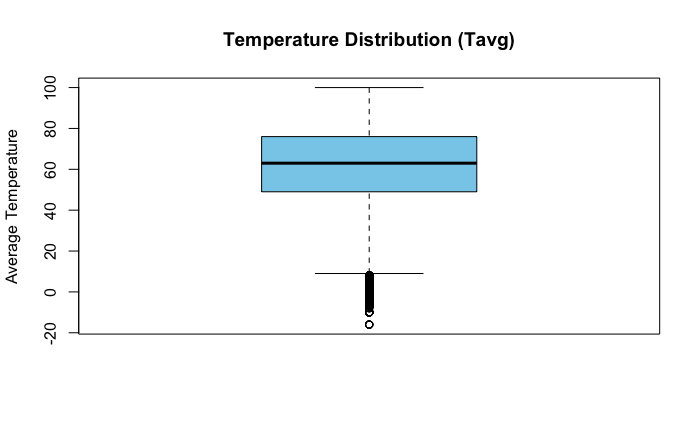

```r
boxplot(df_top3$tavg,
        main = "Temperature Distribution (Tavg)",
        ylab = "Average Temperature",
        col = "Skyblue")
```

Average Temperature vs the frequency.

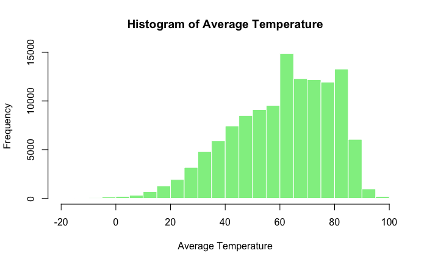

```r
hist(df_top3$tavg,
     main = "Histogram of Average Temperature",
     xlab = "Average Temperature",
     ylab = "Frequency",
     col = "lightgreen",
     border = "white")
```

Average temperature vs unit_solds.

[figure not shown]

```r
ggplot(df_top3, aes(x = tavg, y = mean(units))) +
  geom_bin2d(bins = 5) +
  scale_fill_gradient(low = "lightblue", high = "darkblue") +
  labs(
    title = "2D Histogram: Temperature vs Units",
    x = "Average Temperature",
    y = "Units Sold"
  ) +
  theme_minimal()
```

Visualisation of the Month vs Sales

First, aggregate units by month and then Convert month to factor with proper order (1 = Jan, 12 = Dec). and plot the graph.

```r
monthly_data <- df_top3 %>%
  group_by(month) %>%
  summarise(units = sum(units, na.rm = TRUE)) %>%
  ungroup() %>%
  mutate(month = factor(month, levels = 1:12, labels = month.abb))
```

Monthly top3 item unit sold.

```r
# Filter for top 3 items
df_top3_items <- df %>%
  filter(item_nbr %in% c(5, 9, 45))

# Extract month from date
df_top3_items$month <- month(ymd(df_top3_items$date))

# Aggregate units by month and item
monthly_item_data <- df_top3_items %>%
  group_by(month, item_nbr) %>%
  summarise(units = sum(units, na.rm = TRUE)) %>%
  ungroup() %>%
  mutate(month = factor(month, levels = 1:12, labels = month.abb),
         item_nbr = factor(item_nbr))

# View the data
print(monthly_item_data)
```

```
# A tibble: 36 × 3
   month item_nbr  units
   <fct> <fct>     <int>
 1 Jan   5         95038
 2 Jan   9         97769
 3 Jan   45       104586
 4 Feb   5         77980
 5 Feb   9         86783
 6 Feb   45        90963
 7 Mar   5         79689
 8 Mar   9         88403
 9 Mar   45        96399
10 Apr   5         68725
# ℹ 26 more rows
# ℹ Use `print(n = ...)` to see more rows
```

Visualisation of the monthly sales.

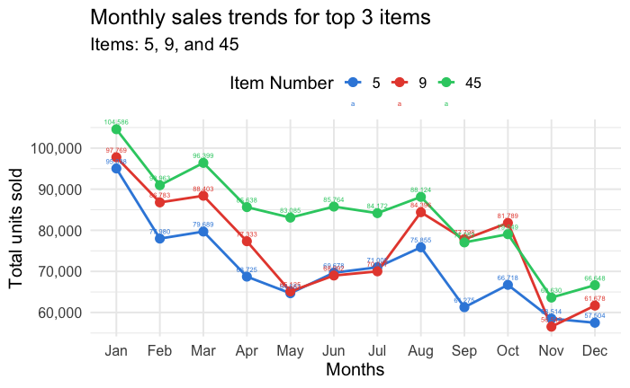

```r
# Option 4: Line Chart (shows trends clearly)
ggplot(monthly_item_data, aes(x = month, y = units, color = item_nbr, group = item_nbr)) +
  geom_line(size = 1) +
  geom_point(size = 3) +
  geom_text(aes(label = scales::comma(units)),
            vjust = -1, size = 2) +
  scale_y_continuous(labels = scales::comma) +
  scale_color_manual(values = c("#378ADD", "#E74C3C", "#2ECC71"),
                     name = "Item Number") +
  labs(
    title    = "Monthly sales trends for top 3 items",
    subtitle = "Items: 5, 9, and 45",
    x        = "Months",
    y        = "Total units sold"
  ) +
  theme_minimal(base_size = 15) +
  theme(
    legend.position = "top"
  )
```

Unit sold by the weather conditions.

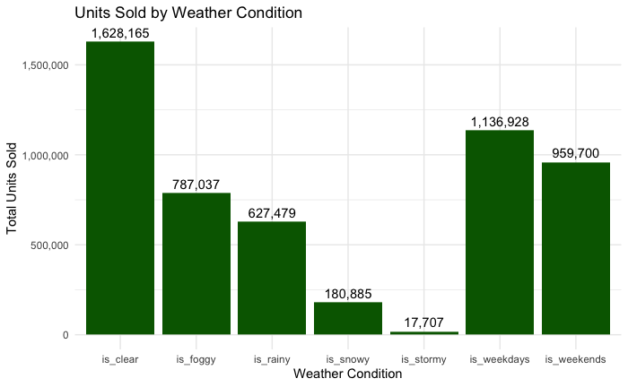

```r
weather_cols <- c("is_clear","is_rainy","is_snowy","is_foggy","is_stormy","is_weekends", "is_weekdays")

weather_units <- df_top3 %>% pivot_longer(
  cols = all_of(weather_cols),
  names_to = "condition",
  values_to = "present") %>%
  filter(present == 1) %>%
  group_by(condition) %>%
             summarise(total_units = sum(units, na.rm = TRUE))

ggplot(weather_units, aes(x = condition, y= total_units)) +
  geom_col(fill = "darkgreen") +
  geom_text(
    aes(label = scales::comma(total_units)),
    vjust = -0.5
  ) +
  scale_y_continuous(labels = scales::comma) +
  labs(
    title = "Units Sold by Weather Condition",
    x = "Weather Condition",
    y = "Total Units Sold"
  ) +
  theme_minimal()
```

```r
NA
NA
```

selecting the correlation features

```r
selected_cols <- df_top3 %>% select(
  where(is.numeric)
)# %>%
  # select(
  #   -c(is_weekends, is_weekdays, is_clear, is_rainy, is_snowy, is_foggy, is_stormy)
  # )
```

```r
correlation <- cor(selected_cols, use = "complete.obs", method = "pearson")

# print(round(correlation, 2))
```

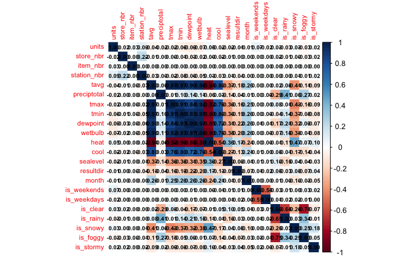

```r
corrplot(correlation, method = "color", type = "full",
         tl.cex = 0.7, number.cex = 0.6, addCoef.col = "black")
```

## Exploring the Distribution of Sales

Summary statistics are calculated for the “units” variable to understand its distribution. Theses includes the minimum, maximum, mean, median, percentage of zero sales, and selected percentile values, which help identify skewness and potential outliers.

```r
df_top3 %>%
  summarise(
    min      = min(units, na.rm = TRUE),
    max      = max(units, na.rm = TRUE),
    mean     = round(mean(units, na.rm = TRUE), 2),
    median   = median(units, na.rm = TRUE),
    pct_zero = round(mean(units == 0) * 100, 2),
    p95      = quantile(units, 0.95, na.rm = TRUE),
    p99      = quantile(units, 0.99, na.rm = TRUE),
    p99_5    = quantile(units, 0.995, na.rm = TRUE)
  )
```

| min | max | mean | median | pct_zero | p95 | p99 | p99_5 |
| --- | --- | --- | --- | --- | --- | --- | --- |
| 0 | 5568 | 22.18 | 0 | 62.1 | 97 | 158 | 188 |

```r
NA
```

```r
# write.csv(df_clean, "product_insights.csv", row.names = FALSE)
```

## Data Preparation

Applying a Log Transformation

A logarithmic transformation (“log1p”) is applied to the sales variable to reduce the effects of skewness and make the distribution more suitable for statistical modelling.

```r
df_top3 <- df_top3 %>%
  mutate(units_log = log1p(units))
```

# Feature Selections

```r
features <-  c("tavg","is_clear","is_rainy","is_snowy","is_foggy","is_stormy","is_weekends", "is_weekdays")
```

## Train, Validation and Test the model

Making the data ready for to fit the model. Each product number are set.

One of the top 3 item, item number 5 is filtered

```r
item_data_5 <- df_top3 %>%
  filter(item_nbr == 5) %>%
  select(units_log, all_of(features)) %>% na.omit()
```

One of the top 3 item, item number 9 is filtered

```r
item_data_9 <- df_top3 %>%
  filter(item_nbr == 9) %>%
  select(units_log, all_of(features)) %>% na.omit()
```

```r
item_data_45 <- df_top3 %>%
  filter(item_nbr == 45) %>%
  select(units_log, all_of(features)) %>% na.omit()
```

In this section, number of rows for top 3 items model number of rows and different indices are created.

```r
set.seed(42)

n5 <- nrow(item_data_5)
n9 <- nrow(item_data_9)
n45 <- nrow(item_data_45)

index_5 <- sample(seq(n5))
index_9 <- sample(seq(n9))
index_45 <- sample(seq(n45))
```

Creating the split for the product no 5

```r
# Create Train/ Validation /Test Split
train_5 <- floor(0.8 * n5)
val_5   <- floor(0.9 * n5)

train_data_5 <- item_data_5[index_5[1:train_5], ]
val_data_5   <- item_data_5[index_5[(train_5 + 1):val_5], ]
test_data_5  <- item_data_5[index_5[(val_5 + 1):n5], ]
```

Creating the split for the product no 9

```r
# Create Train/ Validation /Test Split
train_9 <- floor(0.8 * n9)
val_9   <- floor(0.9 * n9)

train_data_9 <- item_data_9[index_9[1:train_9], ]
val_data_9   <- item_data_9[index_9[(train_9 + 1):val_9], ]
test_data_9  <- item_data_9[index_9[(val_9 + 1):n9], ]
```

Creating the split for the product no 45

```r
# Create Train/ Validation /Test Split
train_45 <- floor(0.8 * n45)
val_45   <- floor(0.9 * n45)

train_data_45 <- item_data_45[index_45[1:train_45], ]
val_data_45   <- item_data_45[index_45[(train_45 + 1):val_45], ]
test_data_45  <- item_data_45[index_45[(val_45 + 1):n45], ]
```

## Fitting the linear regression model for product 5

```r
lm_model_5 <- lm(units_log ~ ., data = train_data_5)
```

Validation test and metric to measure for Linear Regression for Product 5.

```r
# Validation performance
val_preds_5 <- predict(lm_model_5, newdata = val_data_5)
val_rmse_5 <- sqrt(mean((val_preds_5 - val_data_5$units_log)^2))
```

Testing the model and the metric is used, also train metric for the measurement for Product 5.

```r
# Final test performance
test_preds_5 <- predict(lm_model_5, newdata = test_data_5)
test_rmse_5 <- sqrt(mean((test_preds_5 - test_data_5$units_log)^2))
test_mae_5  <- mean(abs(test_preds_5 - test_data_5$units_log))
train_r2_5 <- summary(lm_model_5)$r.squared
```

Displaying the coefficient of product 5.

```r
round(coef(lm_model_5), 3)
```

```
(Intercept)        tavg    is_clear    is_rainy    is_snowy    is_foggy   is_stormy is_weekends is_weekdays
      1.096       0.005       0.071      -0.120       0.043       0.028       0.247       0.168       0.064
```

Displaying the error rate for product 5.

```r
tibble(
  metric = c("Training R2","Validation RMSE", "Testing RMSE", "Testing MAE"),
  value  = round(c(train_r2_5,val_rmse_5, test_rmse_5, test_mae_5), 3)
)
```

| metric | value |
| --- | --- |
| Training R2 | 0.004 |
| Validation RMSE | 1.874 |
| Testing RMSE | 1.874 |
| Testing MAE | 1.782 |

```r
NA
```

Fitting the Linear Regression Model for Product 9

```r
lm_model_9 <- lm(units_log ~ ., data = train_data_9)
```

Validation test and metric to measure for Linear Regression for Product 9.

```r
# Validation performance
val_preds_9 <- predict(lm_model_9, newdata = val_data_9)
val_rmse_9 <- sqrt(mean((val_preds_9 - val_data_9$units_log)^2))
```

Testing the model and the metric is used, also train metric for the measurement for Product 9.

```r
# Final test performance
test_preds_9 <- predict(lm_model_9, newdata = test_data_9)
test_rmse_9 <- sqrt(mean((test_preds_9 - test_data_9$units_log)^2))
test_mae_9  <- mean(abs(test_preds_9 - test_data_9$units_log))
train_r2_9 <- summary(lm_model_9)$r.squared
```

Displaying the coefficient of product 9.

```r
round(coef(lm_model_9), 3)
```

```
(Intercept)        tavg    is_clear    is_rainy    is_snowy    is_foggy   is_stormy is_weekends is_weekdays
      1.472      -0.002      -0.020       0.072       0.188      -0.226       0.187       0.171       0.063
```

Displaying the error rate.

```r
tibble(
  metric = c("Training R2","Validation RMSE", "Testing RMSE", "Testing MAE"),
  value  = round(c(train_r2_9,val_rmse_9, test_rmse_9, test_mae_9), 3)
)
```

| metric | value |
| --- | --- |
| Training R2 | 0.004 |
| Validation RMSE | 1.882 |
| Testing RMSE | 1.871 |
| Testing MAE | 1.717 |

```r
NA
```

Fitting the Linear Regression Model for Product 45.

```r
lm_model_45 <- lm(units_log ~ ., data = train_data_45)
```

Validation test and metric to measure for Linear Regression for Product 45.

```r
# Validation performance
val_preds_45 <- predict(lm_model_45, newdata = val_data_45)
val_rmse_45 <- sqrt(mean((val_preds_45 - val_data_45$units_log)^2))
```

Testing the model and the metric is used, also train metric for the measurement for Product 45.

```r
# Final test performance
test_preds_45 <- predict(lm_model_45, newdata = test_data_45)
test_rmse_45 <- sqrt(mean((test_preds_45 - test_data_45$units_log)^2))
test_mae_45  <- mean(abs(test_preds_45 - test_data_45$units_log))
train_r2_45 <- summary(lm_model_45)$r.squared
```

Displaying the coefficient of product 45.

```r
round(coef(lm_model_45), 3)
```

```
(Intercept)        tavg    is_clear    is_rainy    is_snowy    is_foggy   is_stormy is_weekends is_weekdays
      2.183      -0.012       0.108      -0.076       0.266      -0.324       0.688       0.171       0.074
```

Displaying the error rate.

```r
tibble(
  metric = c("Training R2","Validation RMSE", "Testing RMSE", "Testing MAE"),
  value  = round(c(train_r2_45,val_rmse_45, test_rmse_45, test_mae_45), 3)
)
```

| metric | value |
| --- | --- |
| Training R2 | 0.025 |
| Validation RMSE | 1.986 |
| Testing RMSE | 1.963 |
| Testing MAE | 1.851 |

```r
NA
```

# Decision Tree Models

## Decision Tree 5

```r
dt_model_5 <- rpart(
  units_log ~ .,
  data = train_data_5,
  method = "anova",
  control = rpart.control(cp = 0.001,
                          minsplit = 15
                          )
  )
```

The decision trees regression training and validation and measuring training r2 and validation rmse to measure the error for model 5.

```r
dt_train_preds_5 <- predict(dt_model_5, newdata = train_data_5)
dt_train_r2_5 <- 1 - sum((train_data_5$units_log - dt_train_preds_5)^2) /
                  sum((train_data_5$units_log - mean(train_data_5$units_log))^2)

dt_val_preds_5  <- predict(dt_model_5, newdata = val_data_5)
dt_val_rmse_5   <- sqrt(mean((dt_val_preds_5 - val_data_5$units_log)^2))
```

Running the prediction, test root mean square error(rmse) and mean absolute error(mae) to measure the testing result for model 5.

```r
dt_test_preds_5 <- predict(dt_model_5, newdata = test_data_5)
dt_test_rmse_5  <- sqrt(mean((dt_test_preds_5 - test_data_5$units_log)^2))
dt_test_mae_5   <- mean(abs(dt_test_preds_5 - test_data_5$units_log))
```

Metrics for the decision tree regression model 5.

```r
tibble(
  metric = c("Training R2","Validation RMSE", "Testing RMSE", "Testing MAE"),
  value  = round(c(dt_train_r2_5,dt_val_rmse_5, dt_test_rmse_5, dt_test_mae_5), 3)
)
```

| metric | value |
| --- | --- |
| Training R2 | 0.021 |
| Validation RMSE | 1.852 |
| Testing RMSE | 1.856 |
| Testing MAE | 1.746 |

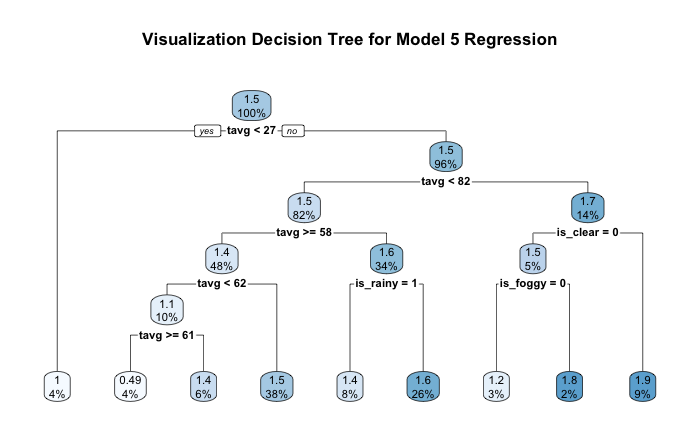

```r
# Visualize pruned tree
rpart.plot(dt_model_5, main = "Visualization Decision Tree for Model 5 Regression")
```

```r
round(dt_model_5$variable.importance, 3)
```

```
     tavg  is_rainy  is_clear  is_foggy  is_snowy is_stormy
 1983.101   295.828   200.470   197.355    54.319     1.176
```

Visualization of the importance on the Model 5.

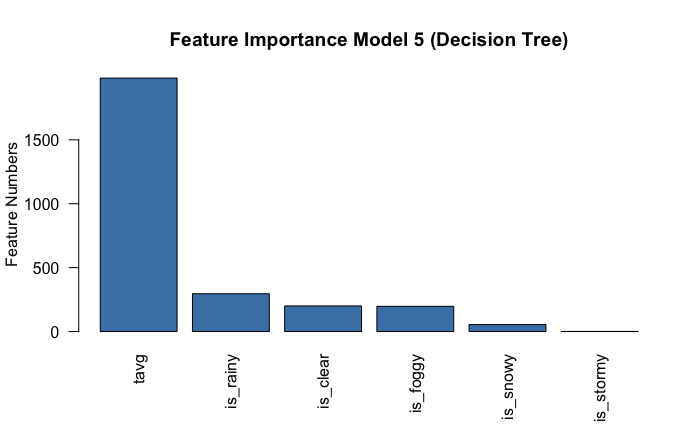

```r
barplot(dt_model_5$variable.importance,
        main = "Feature Importance Model 5 (Decision Tree)",
        ylab = " Feature Numbers",
        las = 2,
        col = "steelblue")
```

## Decision Tree 9

```r
dt_model_9 <- rpart(
  units_log ~ .,
  data = train_data_9,
  method = "anova",              # regression tree (units is numeric)
  control = rpart.control(cp = 0.001,
                          minsplit = 20
                          )
  )
```

The decision trees regression training and validation and measuring training r2 and validation rmse to measure the error for model 9.

```r
dt_train_preds_9 <- predict(dt_model_9, newdata = train_data_9)
dt_train_r2_9 <- 1 - sum((train_data_5$units_log - dt_train_preds_9)^2) /
                  sum((train_data_9$units_log - mean(train_data_9$units_log))^2)

dt_val_preds_9  <- predict(dt_model_9, newdata = val_data_9)
dt_val_rmse_9   <- sqrt(mean((dt_val_preds_9 - val_data_9$units_log)^2))
```

Running the prediction, test root mean square error(rmse) and mean absolute error(mae) to measure the testing result for model 9.

```r
dt_test_preds_9 <- predict(dt_model_9, newdata = test_data_9)
dt_test_rmse_9  <- sqrt(mean((dt_test_preds_9 - test_data_9$units_log)^2))
dt_test_mae_9   <- mean(abs(dt_test_preds_9 - test_data_9$units_log))
```

Metrics for the Decision Tree Regression model for model 9.

```r
tibble(
  metric = c("Training R2","Validation RMSE", "Testing RMSE", "Testing MAE"),
  value  = round(c(dt_train_r2_9,dt_val_rmse_9, dt_test_rmse_9, dt_test_mae_9), 3)
)
```

| metric | value |
| --- | --- |
| Training R2 | -0.003 |
| Validation RMSE | 1.872 |
| Testing RMSE | 1.860 |
| Testing MAE | 1.700 |

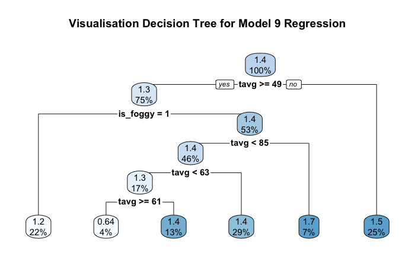

```r
rpart.plot(dt_model_9, main = "Visualisation Decision Tree for Model 9 Regression")
```

```r
round(dt_model_9$variable.importance, 3)
```

```
     tavg  is_foggy  is_clear  is_snowy  is_rainy is_stormy
 1124.878   265.554   133.473    38.283    21.240     1.692
```

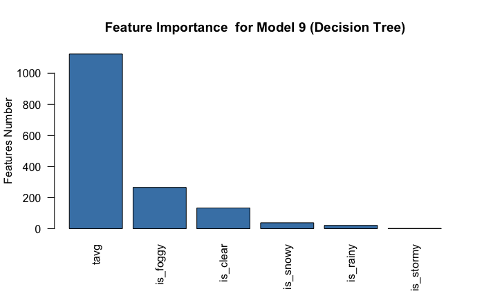

```r
barplot(dt_model_9$variable.importance,
        main = "Feature Importance  for Model 9 (Decision Tree)",
        ylab = " Features Number",
        las = 2,
        col = "steelblue")
```

## Decision Tree 45

```r
dt_model_45 <- rpart(
  units_log ~ .,
  data = train_data_45,
  method = "anova",              # regression tree (units is numeric)
  control = rpart.control(cp = 0.001,
                          minsplit = 15
                          )
  )
```

The decision trees regression training and validation and measuring training r2 and validation rmse to measure the error for model 45.

```r
dt_train_preds_45 <- predict(dt_model_45, newdata = train_data_45)
dt_train_r2_45 <- 1 - sum((train_data_45$units_log - dt_train_preds_45)^2) /
                  sum((train_data_45$units_log - mean(train_data_45$units_log))^2)

dt_val_preds_45  <- predict(dt_model_45, newdata = val_data_45)
dt_val_rmse_45   <- sqrt(mean((dt_val_preds_45 - val_data_45$units_log)^2))
```

Running the prediction, test root mean square error(rmse) and mean absolute error(mae) to measure the testing result for model 45.

```r
dt_test_preds_45 <- predict(dt_model_45, newdata = test_data_45)
dt_test_rmse_45  <- sqrt(mean((dt_test_preds_45 - test_data_45$units_log)^2))
dt_test_mae_45   <- mean(abs(dt_test_preds_45 - test_data_45$units_log))
```

```r
tibble(
  metric = c("Training R2","Validation RMSE", "Testing RMSE", "Testing MAE"),
  value  = round(c(dt_train_r2_45,dt_val_rmse_45, dt_test_rmse_45, dt_test_mae_45), 3)
)
```

| metric | value |
| --- | --- |
| Training R2 | 0.060 |
| Validation RMSE | 1.959 |
| Testing RMSE | 1.934 |
| Testing MAE | 1.789 |

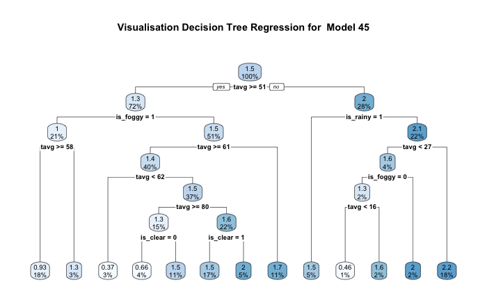

```r
rpart.plot(dt_model_45, main = "Visualisation Decision Tree Regression for  Model 45")
```

looking for the importance of the features used for the prediction model 45.

```r
round(dt_model_45$variable.importance, 3)
```

```
     tavg  is_clear  is_rainy  is_foggy  is_snowy is_stormy
 5454.288  1509.486  1230.971  1209.374   599.760    27.924
```

Visualization of the importance on the Model 45.

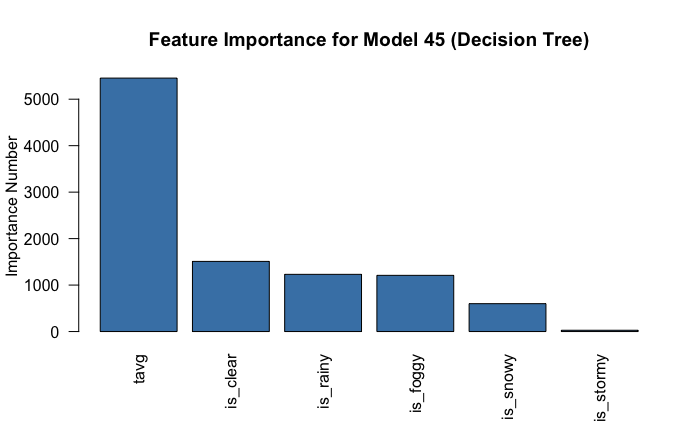

```r
barplot(dt_model_45$variable.importance,
        main = "Feature Importance for Model 45 (Decision Tree)",
        ylab = "Importance Number",
        las = 2,
        col = "steelblue")
```